# Assignment 4: Equity Analysis of Educational Attainment by Race in San Francisco County

David Ludeke

10/19/2021

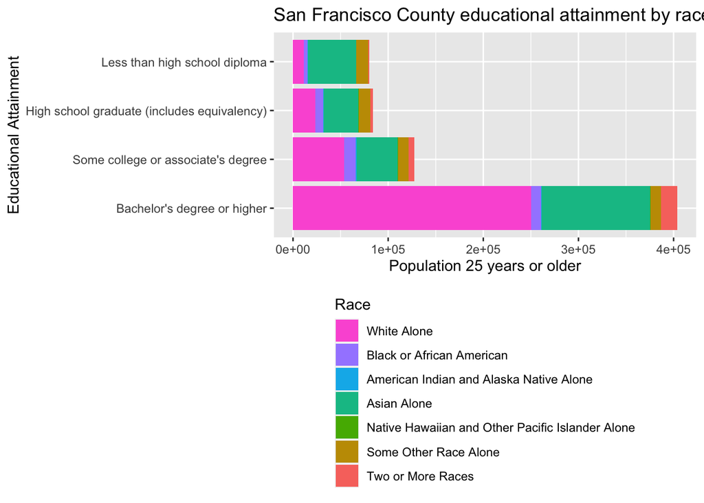

Stacked bar graph displaying the population 25 years or older by race within each of the four educational attainment tiers.

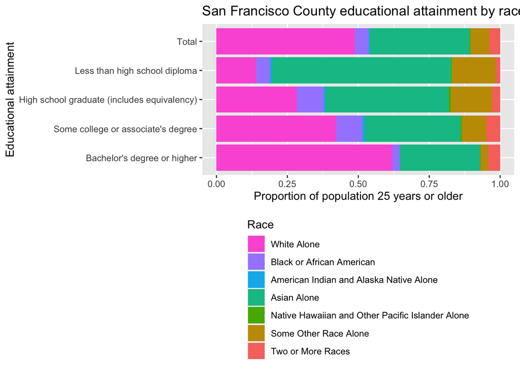

Filled bar graph displaying the proportions of the population 25 years or older by race within each of the four educational attainment tiers, compared against the total proportion of each race in the population of San Francisco County.

Based on the two bar graphs above, it is clear that San Francisco County faces extremely disproportionate educational attainment by race. Most glaringly, white households are underrepresented for lower educational attainment outcomes and overrepresented for the highest outcome, “Bachelor’s degree or higher.” By contrast Asian households are overrepresented in the lowest educational attainment outcome, “less than high school diploma.” These data visualizations illustrate the need for San Francisco County to address its disproportionate educational attainment outcomes. However, it also raises important historical questions: how does the history of immigration in San Francisco contextualize some of these findings? What will this data look like in 25 years when the data is collected for young people now who are in the midst of attaining their education?